# Cost-effectiveness plane

## Introduction

#### R code

To calculate these in BCEA we use the `bcea()` function.

```r
data("Vaccine")

he <- bcea(eff, cost)
```

```
#> No reference selected. Defaulting to first intervention.
```

The plot defaults to base R plotting. Type of plot can be set explicitly using the `graph` argument.

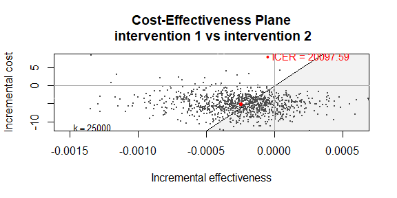

```r
ceplane.plot(he, graph = "base")
```

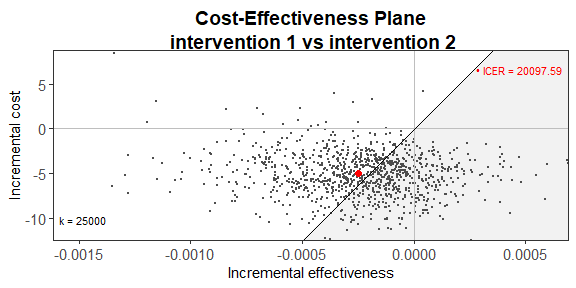

```r
ceplane.plot(he, graph = "ggplot2")
```

```r
# ceac.plot(he, graph = "plotly")
```

Other plotting arguments can be specified such as title, line colours and theme.

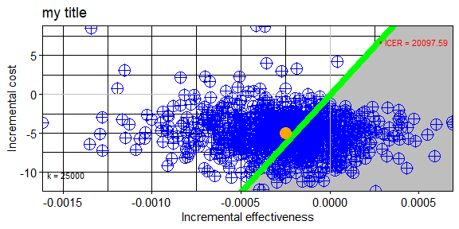

```r
ceplane.plot(he,
             graph = "ggplot2",
             title = "my title",
             line = list(color = "green", size = 3),
             point = list(color = "blue", shape = 10, size = 5),
             icer = list(color = "orange", size = 5),
             area = list(fill = "grey"),
             theme = theme_linedraw())
```

If you only what the mean point then you can suppress the sample points by passing size `NA`.

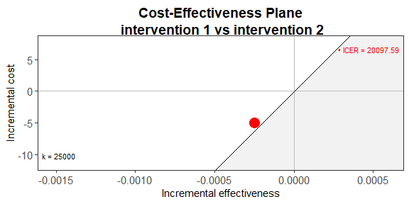

```r
ceplane.plot(he,
             graph = "ggplot2",
             point = list(size = NA),
             icer = list(size = 5))
```

## Multiple interventions

This situation is when there are more than two interventions to consider.

#### R code

```r
data("Smoking")

he <- bcea(eff, cost, ref = 4)
# str(he)
```

Basic plots with defaults.

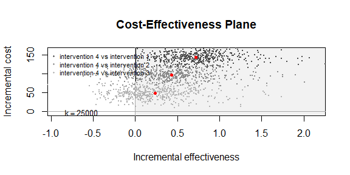

```r
ceplane.plot(he)
```

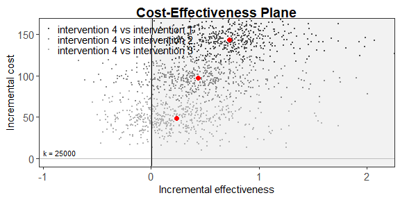

```r
ceplane.plot(he, graph = "ggplot2")
```

The font size can be adjusted using the `text` argument.

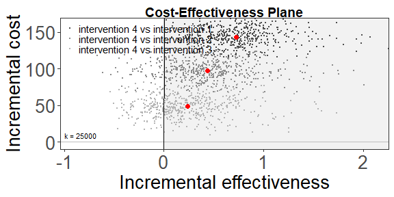

```r
ceplane.plot(he, graph = "ggplot2", text = list(size = 20))
```

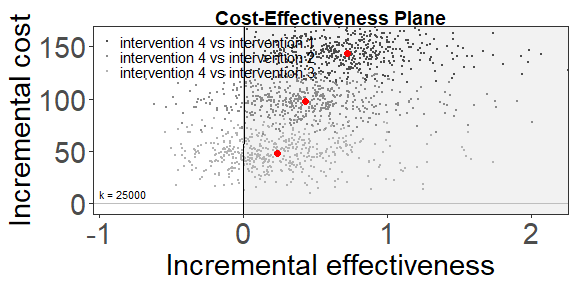

```r
ceplane.plot(he, graph = "ggplot2", text = list(size = rel(2)))  # relative scaling, double size
```

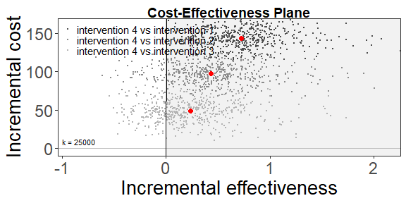

```r
# equivalent but more flexible and direct
ceplane.plot(he, graph = "ggplot2") +
  theme(axis.text = element_text(size = 18),
        axis.title.x = element_text(size = 20),
        axis.title.y = element_text(size = 20))
```

Numerous different styling arguments can be provided.

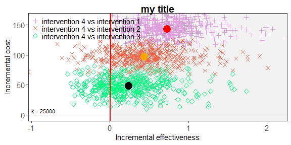

```r
ceplane.plot(he,
             graph = "ggplot2",
             title = "my title",
             line = list(color = "red", size = 1),
             point = list(color = c("plum", "tomato", "springgreen"), shape = 3:5, size = 2),
             icer = list(color = c("red", "orange", "black"), size = 5))
```

There are various different ways to reposition the legend.

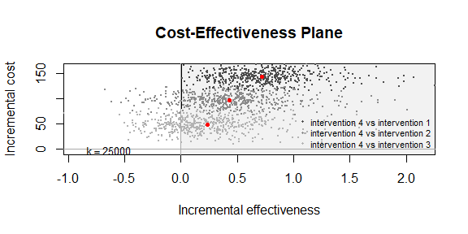

```r
ceplane.plot(he, pos = FALSE) # bottom right
```

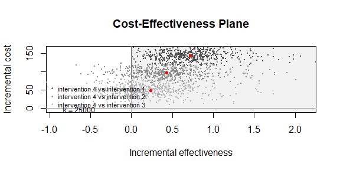

```r
ceplane.plot(he, pos = c(0, 0))
```

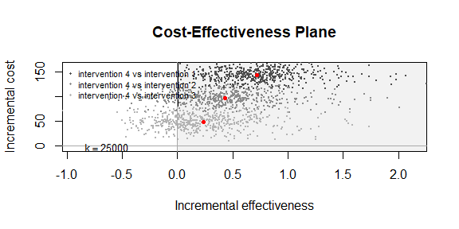

```r
ceplane.plot(he, pos = c(0, 1))
```

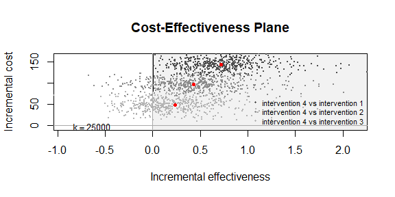

```r
ceplane.plot(he, pos = c(1, 0))
```

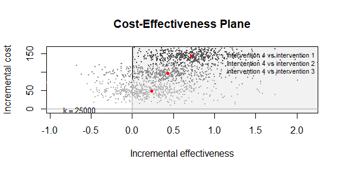

```r
ceplane.plot(he, pos = c(1, 1))
```

### Willingness-to-pay label

For `{ggplot2}` we can modify the willingness-to-pay label e.g. “k = 25000”.

The default is

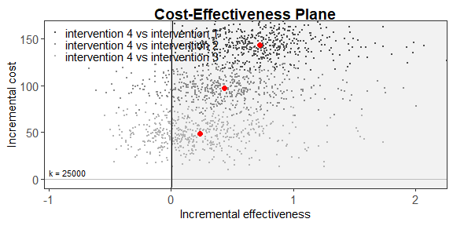

```r
ceplane.plot(he, graph = "ggplot2")
```

The simplest argument is to set the value of the willingness-to-pay threshold using `wtp`.

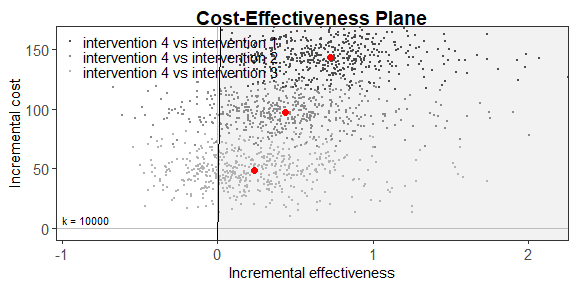

```r
ceplane.plot(he, graph = "ggplot2", wtp = 10000)
```

Alternatively, we can pass a list of arguments to `wtp` to modify the appearance of the label.

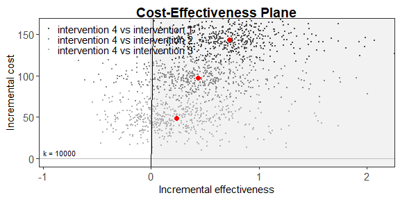

```r
ceplane.plot(he, graph = "ggplot2", wtp = list(value = 10000))
```

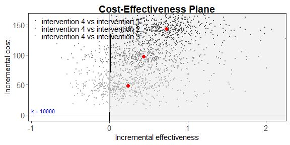

```r
ceplane.plot(he, graph = "ggplot2", wtp = list(value = 10000, colour = "blue"))
```

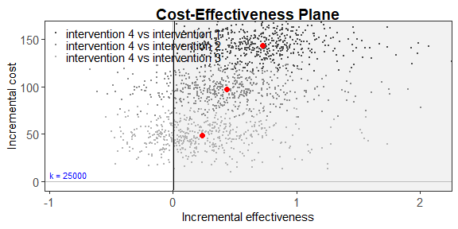

```r
ceplane.plot(he, graph = "ggplot2", wtp = list(colour = "blue"))
```

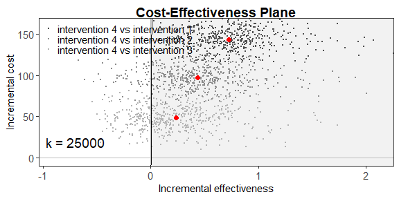

```r
ceplane.plot(he, graph = "ggplot2", wtp = list(size = 5))
```

To hide the text assign `size = 0`.

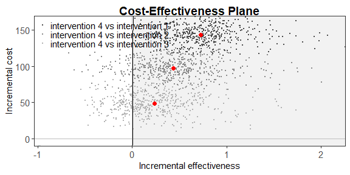

```r
ceplane.plot(he, graph = "ggplot2", wtp = list(size = 0))
```

The label is placed at the left hand side of the plot next to the willingness-to-pay line by default. When this would mean the label is off the bottom of the plot it is positioned at the bottom left corner.

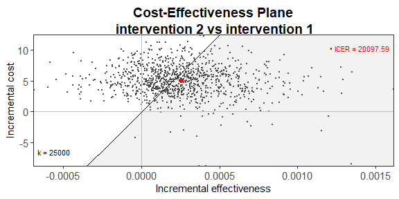

```r
data("Vaccine")
he <- bcea(eff, cost, ref=2)

ceplane.plot(he, graph = "ggplot2")
```

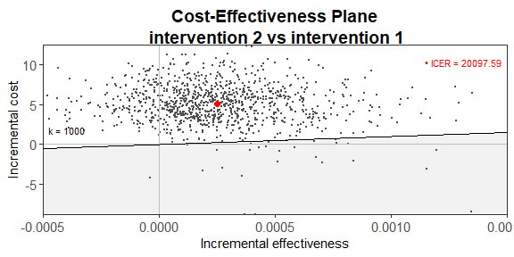

```r
ceplane.plot(he, graph = "ggplot2", wtp = 1000, xlim = c(-0.0005, 0.0015))
```

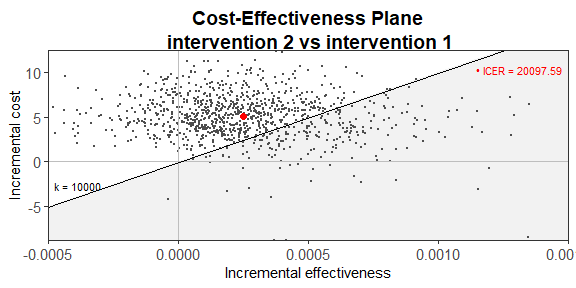

```r
ceplane.plot(he, graph = "ggplot2", wtp = 10000, xlim = c(-0.0005, 0.0015))
```

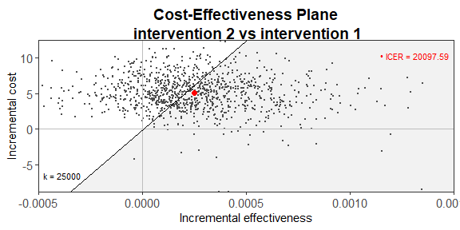

```r
ceplane.plot(he, graph = "ggplot2", wtp = 25000, xlim = c(-0.0005, 0.0015))
```

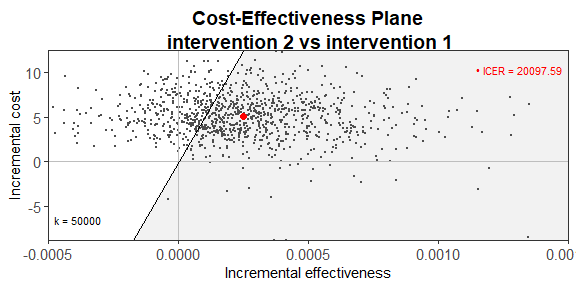

```r
ceplane.plot(he, graph = "ggplot2", wtp = 50000, xlim = c(-0.0005, 0.0015))
```

The position of the label can be adjusted using the `label.pos` argument and a logical value.

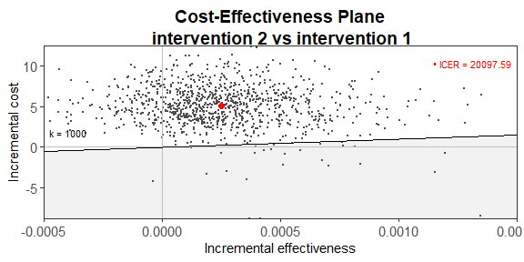

```r
ceplane.plot(he, graph = "ggplot2", wtp = 1000, xlim = c(-0.0005, 0.0015), label.pos = TRUE)
```

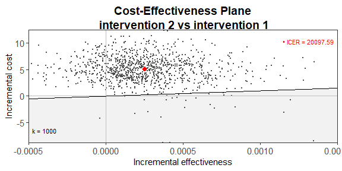

```r
ceplane.plot(he, graph = "ggplot2", wtp = 1000, xlim = c(-0.0005, 0.0015), label.pos = FALSE)
```

A direct way of specifying the position of the label is to use the `wtp` argument and set the `y` value in a list.

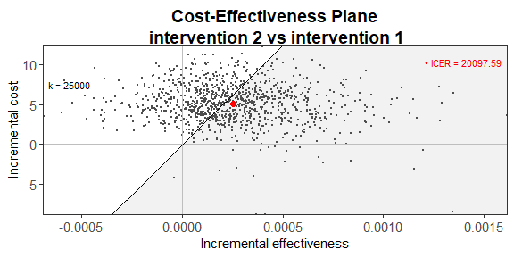

```r
ceplane.plot(he, graph = "ggplot2", wtp = list(y = 8))
```

For base `R`

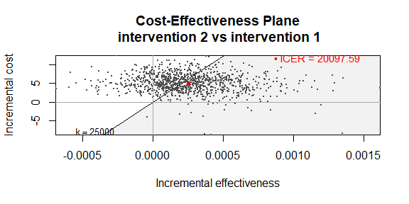

```r
ceplane.plot(he)  # default
```

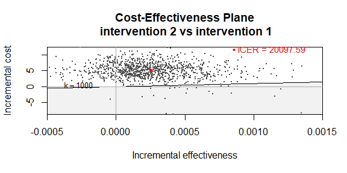

```r
ceplane.plot(he, wtp = 1000, xlim = c(-0.0005, 0.0015))
```

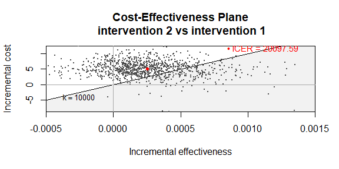

```r
ceplane.plot(he, wtp = 10000, xlim = c(-0.0005, 0.0015))
```

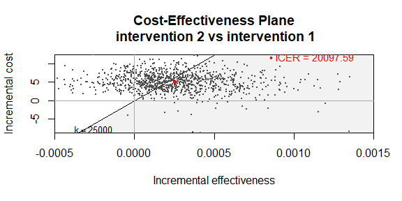

```r
ceplane.plot(he, wtp = 25000, xlim = c(-0.0005, 0.0015))
```

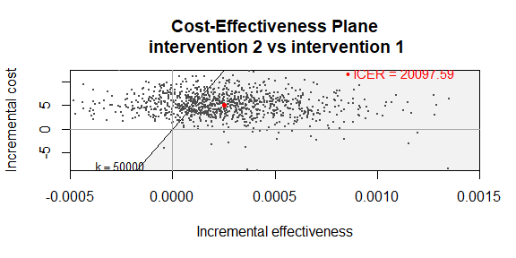

```r
ceplane.plot(he, wtp = 50000, xlim = c(-0.0005, 0.0015))
```

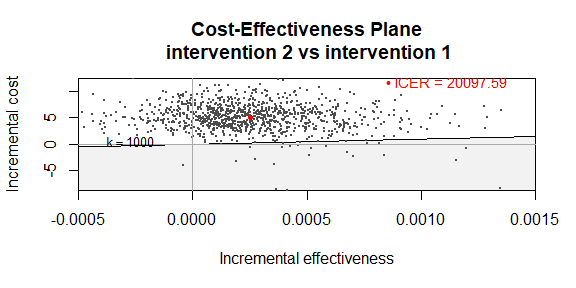

```r
ceplane.plot(he, wtp = 1000, xlim = c(-0.0005, 0.0015), label.pos = TRUE)
```

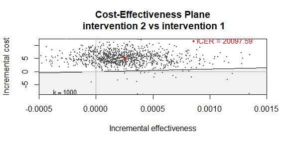

```r
ceplane.plot(he, wtp = 1000, xlim = c(-0.0005, 0.0015), label.pos = FALSE)
```

```r
##TODO: not yet implemented ggplot syntax for base R

# ceplane.plot(he, wtp = list(value = 10000))
# ceplane.plot(he, wtp = list(value = 10000, colour = "blue"))
# ceplane.plot(he, wtp = list(colour = "blue"))
# ceplane.plot(he, wtp = list(y = 8))
# ceplane.plot(he, wtp = list(size = 5))
#
# # to hide text
# ceplane.plot(he, wtp = list(size = 0))
```